# COVID-19

### Mortality

When reproducing the KNN model to predict mortality rather than cases, the best number of neighbors to use in the analysis is 9 instead of 7.

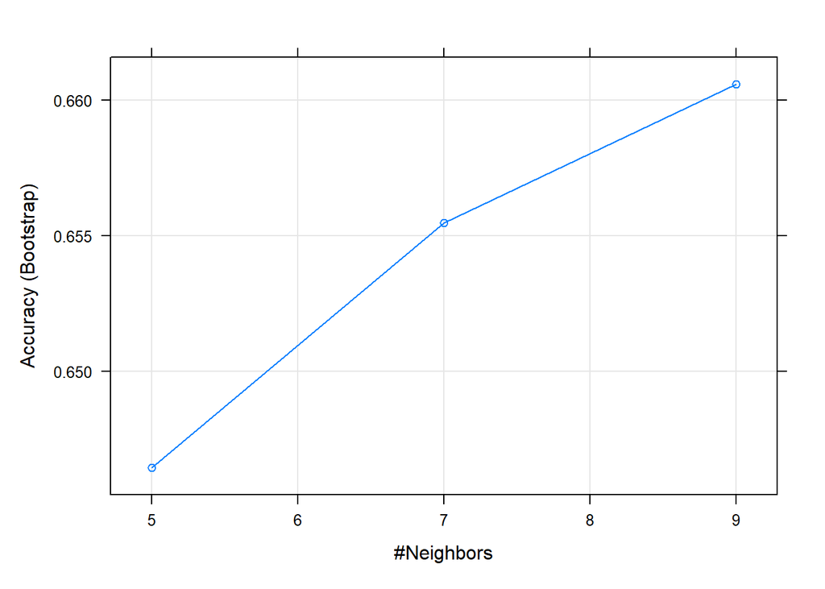

```r
#Create the knn model
knnm_model <- caret::train(
  deathcategory~.,
  data = dfm_cc_training ,
  method = "knn",
  na.action = na.omit
)

#plot the tuned model to see accuracy against number of neighbors tested
plot(knnm_model) #best number of neighbors was 9
```

```r
#create predictions on the training data
knnm_training_predictions <- predict(knnm_model, dfm_cc_training )

#use a confusion matrix to assess accuracy on training data
knnm_training_cnfsmtrx <- confusionMatrix(dfm_cc_training $deathcategory, knnm_training_predictions)
knnm_training_cnfsmtrx$overall[1]
```

```
##  Accuracy
## 0.7458741
```

The accuracy on the training data for mortality is 74%. The Confusion Matrix below shows that the accuracy on the testing data is 68%.

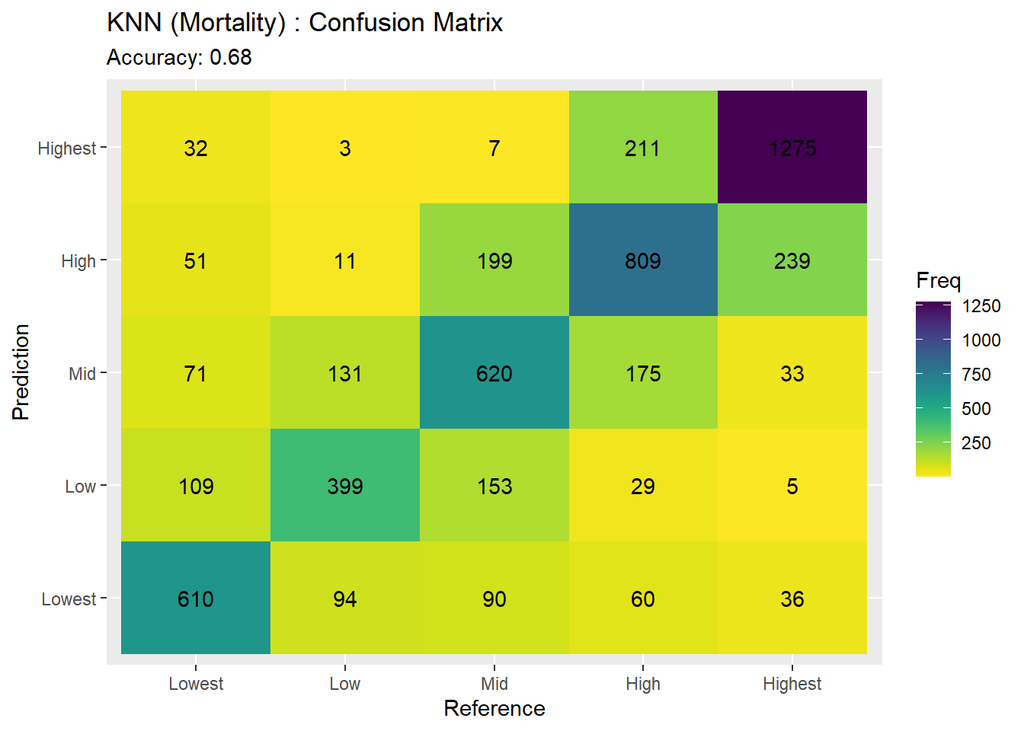

```r
#create predictions on the testing data
knnm_testing_predictions <- predict(knnm_model, dfm_cc_testing )

#use a confusion matrix to assess
knnm_testing_cnfsmtrx <- confusionMatrix(dfm_cc_testing $deathcategory, knnm_testing_predictions)

#visualize the confusion matrix on the testing data
cmheatmap("KNN (Mortality)", knnm_testing_cnfsmtrx)
```

### KNN Mortality on one country only

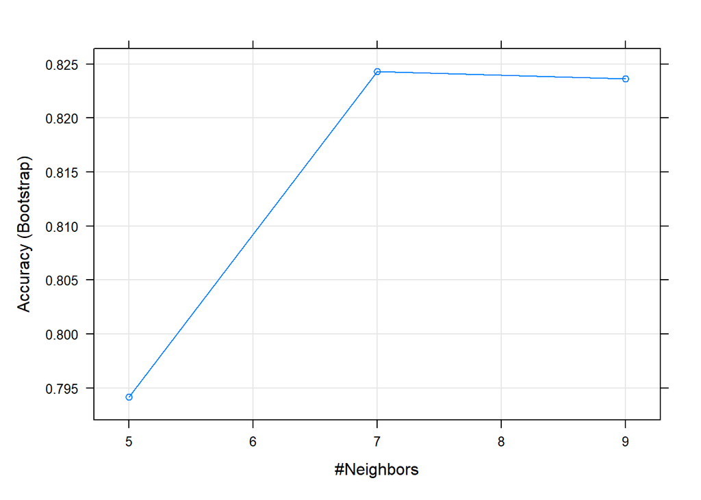

```r
#Population of Italy is 60367471
dfm_1c_training <- filter(dfm_cc_training , population == 60367471)

dfm_1c_testing <- filter(dfm_cc_testing ,  population == 60367471)

#Create the knn model for Italy only
knnm_IT_model_tuned <- caret::train(
  deathcategory~.,
  data = dfm_1c_training,
  method = "knn",
  na.action = na.omit
)

#plot the tuned model to see accuracy against number of neighbors tested
plot(knnm_IT_model_tuned) #best number of neighbors was 9
```

```r
#create predictions on the training data
knnm_IT_training_predictions <- predict(knnm_IT_model_tuned, dfm_1c_training)

#use a confusion matrix to assess accuracy on training data
knnm_IT_training_cnfsmtrx <- confusionMatrix(dfm_1c_training$deathcategory, knnm_IT_training_predictions)
knnm_IT_training_cnfsmtrx$overall[1]
```

```
##  Accuracy
## 0.8538961
```

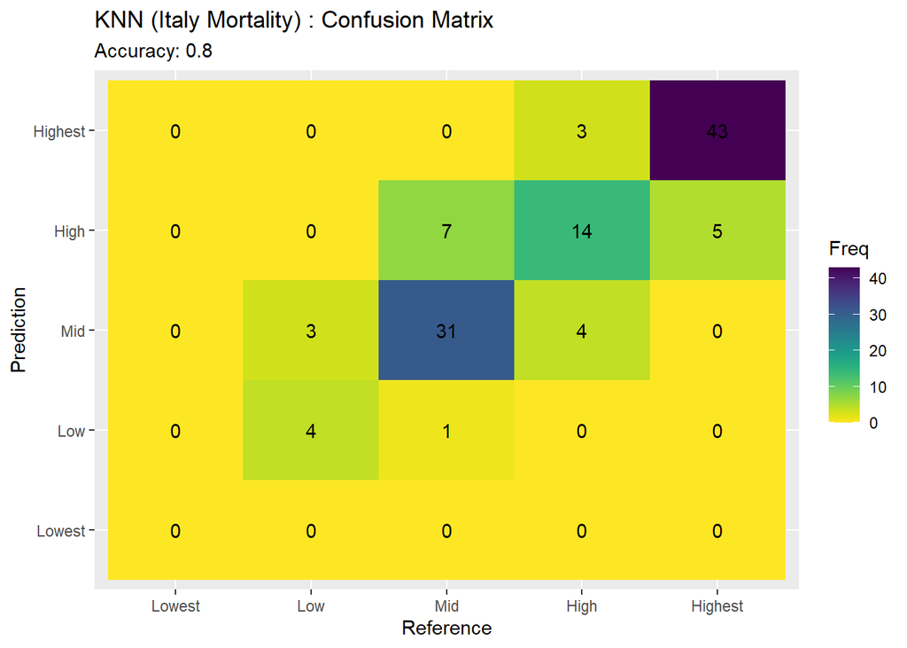

```r
#create predictions on the testing data
knnm_IT_testing_predictions <- predict(knnm_IT_model_tuned, dfm_1c_testing)

#use a confusion matrix to assess
knnm_IT_testing_cnfsmtrx <- confusionMatrix(dfm_1c_testing$deathcategory, knnm_IT_testing_predictions)

#visualize the confusion matrix on the testing data
cmheatmap("KNN (Italy Mortality)", knnm_IT_testing_cnfsmtrx)
```

## Naive Bayes

Naive Bayes is a supervised machine learning algorithm that uses statistics to solve classification problems. This model works by calculating the probability that an unknown data point belongs to a certain class (outcome), assuming that all features in the model are independent of each other (have no combined effects upon the outcome). In this case, the outcomes of interest will be both the daily mortality rate and case count discretized into 5 levels from lowest to highest. The predictors used to train the model will be all variables included in the data set such as the number of new vaccinations, number of tests, hospital admissions, the stringency index, the reproduction number of the virus at that time, and static country characteristics such as the Gross Domestic Product (GDP), population and life expectancy. During pre-processing, the data was split into training and testing data. After the model is trained on the training data, the testing data will be used to assess how accurate the model is at predicting what level of mortality and/or cases a certain country would experience on any given day, based on the other factors.

The algorithm will calculate the mean and standard deviation for each predictor, and compare that against the “apriori,” which is the likelihood of an observation randomly falling into each category. The first outcome to be assessed in this study will be mortality.

### Mortality

```r
#create the basic naive bayes model
nbm_model <- e1071::naiveBayes(deathcategory~.,
                       data = dfm_training)

#create a prediction based on the training data
nbm_training_predictions <- predict(nbm_model, dfm_training)

#create a prediction on the testing data
nbm_testing_predictions <- predict(nbm_model, dfm_testing)

#review the apriori, which shows the number of observations within each class
nbm_model$apriori
```

```
## Y
## Lowest (0-0.1)  Low (0.1-0.5)  Mid (0.5-1.3) High (1.3-3.8) Highest (>3.8)
##          36589          12158          12237          12169          12269
```

The apriori figure above shows the distribution of training data observations in each category. It should be noted that the lowest bin, with a daily mortality rate below 0.1 has a larger share of observations in it, due to the skew of the original data.

```r
#check how well the prediction did on training data using a confusion matrix
nbm_training_cnfsmtrx <- confusionMatrix(dfm_training$deathcategory, nbm_training_predictions)
nbm_training_cnfsmtrx$overall[1]
```

```
##  Accuracy
## 0.4088993
```

The model only reached a 41% accuracy level when using the training data. Below, the model will be tested against the testing data set, which was not used to train the model.

```r
#check how well the prediction did on testing data using a confusion matrix
nbm_testing_cnfsmtrx <- confusionMatrix(dfm_testing$deathcategory, nbm_testing_predictions)
nbm_testing_cnfsmtrx$overall
```

```
##       Accuracy          Kappa  AccuracyLower  AccuracyUpper   AccuracyNull
##      0.4078505      0.2594980      0.4028103      0.4129054      0.2719277
## AccuracyPValue  McnemarPValue
##      0.0000000      0.0000000
```

The output of the Confusion Matrix shows that the “No Information Rate” for this model would be 27%, meaning that if each observation was randomly assigned to a group with no information available to help make predictions, it would likely still be correct about 27% of the time. The model’s accuracy is 41%, so it does perform better than it would were there be to no information available. The Confusion Matrix is represented visually below, and it can be seen that the model appears to be predicting that mortality would be lower than it actually is.

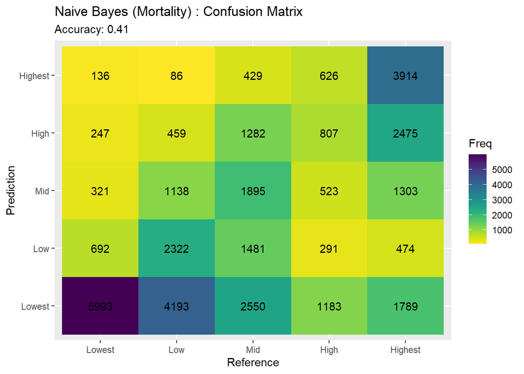

```r
#visualize the confusion matrix on the testing data
cmheatmap("Naive Bayes (Mortality)", nbm_testing_cnfsmtrx)
```

The following tables show the mean and standard deviation of a few key variables for each classification. It is interesting to note that as the GDP of a country increases, it appears that the daily mortality rate is also increasing, so in this dataset, wealthier countries experienced (or at least reported) more daily mortality than lower income countries.

Not surprisingly, the data below shows that the mortality rate increases as the cases increase. The mean number of new cases per million on a day with the lowest mortality was only 57, while the mean number of cases on a day with the highest mortality levels was 566.

```r
#look at some of the probabilities (first column is mean for that class, second is standard deviation)
nbm_model$tables$gdp_per_capita
```

```
##                 gdp_per_capita
## Y                    [,1]     [,2]
##   Lowest (0-0.1) 16403.50 21394.11
##   Low (0.1-0.5)  16464.00 18338.88
##   Mid (0.5-1.3)  22189.97 20646.79
##   High (1.3-3.8) 22983.60 17899.33
##   Highest (>3.8) 22665.73 14554.28
```

```r
nbm_model$tables$new_cases_per_million
```

```
##                 new_cases_per_million
## Y                     [,1]     [,2]
##   Lowest (0-0.1)  57.80228 391.2811
##   Low (0.1-0.5)   34.98083 267.2379
##   Mid (0.5-1.3)  107.22675 305.2028
##   High (1.3-3.8) 285.61812 682.5248
##   Highest (>3.8) 566.66276 989.8423
```

### Naive Bayes on cases

Because the daily case rate appears to be a strong predictor of the daily mortality rate, a model will be developed to attempt to predict the daily case rate as well. The process will be identical as above, using Naïve Bayes again.

```r
#create the basic naive bayes model
nbc_model <- e1071::naiveBayes(casecategory~.,
                       data = dfc_training)

#create a prediction based on the training data
nbc_training_predictions <- predict(nbc_model, dfc_training)

#create a prediction on the testing data
nbc_testing_predictions <- predict(nbc_model, dfc_testing)

#review the apriori, which shows the number of observations within each class
nbc_model$apriori
```

```
## Y
##   Lowest (0-1)     Low (1-11)    Mid (11-55)  High (55-198) Highest (>198)
##          17966          18018          18019          17826          17985
```

```r
#check how well the prediction did using a confusion matrix
nbc_training_cnfsmtrx <- confusionMatrix(dfc_training$casecategory, nbc_training_predictions)
nbc_training_cnfsmtrx$overall[1]
```

```
##  Accuracy
## 0.3937582
```

The Naïve Bayes model is only able to predict the daily case rate on training data at an accuracy level of 39%. This is slightly worse than the model to predict daily mortality. The model will be assessed against the testing data as well.

```r
#check how well the prediction did using a confusion matrix
nbc_testing_cnfsmtrx <- confusionMatrix(dfc_testing$casecategory, nbc_testing_predictions)
nbc_testing_cnfsmtrx$overall
```

```
##       Accuracy          Kappa  AccuracyLower  AccuracyUpper   AccuracyNull
##   3.934166e-01   2.416738e-01   3.885316e-01   3.983178e-01   3.077343e-01
## AccuracyPValue  McnemarPValue
##  2.995731e-278   0.000000e+00
```

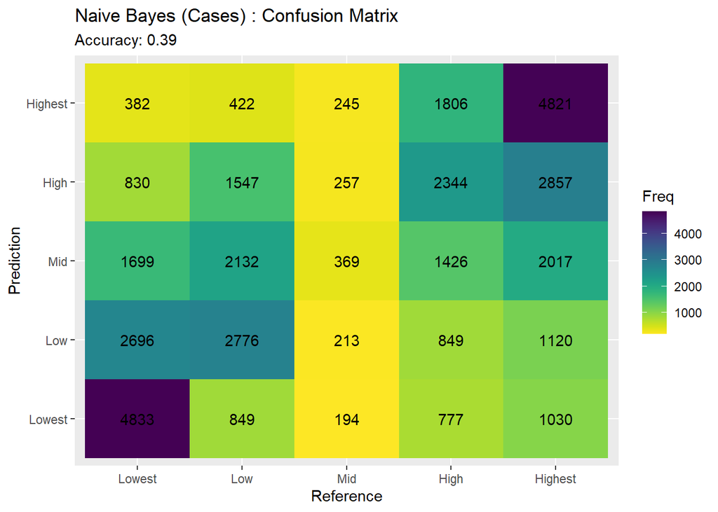

```r
#visualize the confusion matrix on the testing data
cmheatmap("Naive Bayes (Cases)", nbc_testing_cnfsmtrx)
```

The accuracy level for the Naïve Bayes model on testing data is still only 39%. The No Information Rate is 31%, so this model does not perform much better than randomly assigning observations to an outcome group. The heatmap below provides a visual representation of the Confusion Matrix. It should be noted that this particular model is markedly misclassifying days where the case rate is in the mid-range.

```r
#look at some of the probabilities (first column is mean for that class, second is standard deviation)
nbc_model$tables$gdp_per_capita
```

```
##                 gdp_per_capita
## Y                    [,1]     [,2]
##   Lowest (0-1)   12317.25 16283.87
##   Low (1-11)     12240.30 17042.29
##   Mid (11-55)    17448.77 17742.34
##   High (55-198)  24127.44 21825.52
##   Highest (>198) 28259.91 19704.12
```

### Tuned Naive Bayes (Cases)

Both Naïve Bayes models (predicting mortality and case rates) performed poorly, only slightly outperforming what could be expected randomly. Naïve Bayes models have parameters that can be tuned though, so the code below will use a tuning grid to try several different iterations of the model, to find the best combination of parameters. In order to use the tuning grid, the data required some additional pre-processing, including removing observations that did not have complete data available. This modified dataset will be used to train this model.

```r
#create a tuning grid
nb_grid <- expand.grid(usekernel = c(TRUE, FALSE),
                       laplace = c(0, 0.5, 1),
                       adjust = c(0.75, 1, 1.25, 1.5))

# Create naive bayes tuned model
set.seed(92)
nbc_model_tuned <- train(casecategory~.,
                                data = dfc_cc_training,
                                method = "naive_bayes",
                                usepoisson = TRUE,
                                tuneGrid = nb_grid,
                                na.action = "na.omit")

# View the selected tuning parameters
nbc_model_tuned$finalModel$tuneValue
```

|  | laplace | usekernel | adjust |
| --- | --- | --- | --- |
| 13 | 0 | TRUE | 0.75 |

The tuning grid identified the best combination of parameters to increase the accuracy of the Naïve Bayes model on this data set. The best combination of parameters is to have laplace smoothing set at 0, to use a kernel, and set the adjustment at 0.75. The model created with these parameters is assessed below.

```r
#create a prediction based on the training data
nbc_tuned_training_predictions <- predict(nbc_model_tuned, dfc_cc_training)

#create a prediction on the testing data
nbc_tuned_testing_predictions <- predict(nbc_model_tuned, dfc_cc_testing)

#check how well the prediction did using a confusion matrix
nbc_tuned_training_cnfsmtrx <- confusionMatrix(dfc_cc_training$casecategory, nbc_tuned_training_predictions)

#check how well the prediction did using a confusion matrix
nbc_tuned_testing_cnfsmtrx <- confusionMatrix(dfc_cc_testing$casecategory, nbc_tuned_testing_predictions)
nbc_tuned_testing_cnfsmtrx
```

```
## Confusion Matrix and Statistics
##
##                 Reference
## Prediction       Lowest (0-1) Low (1-11) Mid (11-55) High (55-198)
##   Lowest (0-1)             96         32          16            26
##   Low (1-11)                0        198          68             6
##   Mid (11-55)              17        144         387           178
##   High (55-198)           107         82         323           599
##   Highest (>198)          157         20         194           384
##                 Reference
## Prediction       Highest (>198)
##   Lowest (0-1)               31
##   Low (1-11)                 53
##   Mid (11-55)               228
##   High (55-198)             650
##   Highest (>198)           1713
##
## Overall Statistics
##
##                Accuracy : 0.5243
##                  95% CI : (0.5112, 0.5373)
##     No Information Rate : 0.4686
##     P-Value [Acc > NIR] : < 2.2e-16
##
##                   Kappa : 0.3174
##
##  Mcnemar's Test P-Value : < 2.2e-16
##
## Statistics by Class:
##
##                      Class: Lowest (0-1) Class: Low (1-11) Class: Mid (11-55)
## Sensitivity                      0.25464           0.41597            0.39170
## Specificity                      0.98031           0.97573            0.87990
## Pos Pred Value                   0.47761           0.60923            0.40566
## Neg Pred Value                   0.94898           0.94837            0.87361
## Prevalence                       0.06604           0.08338            0.17306
## Detection Rate                   0.01682           0.03468            0.06779
## Detection Prevalence             0.03521           0.05693            0.16710
## Balanced Accuracy                0.61747           0.69585            0.63580
##                      Class: High (55-198) Class: Highest (>198)
## Sensitivity                        0.5021                0.6404
## Specificity                        0.7427                0.7512
## Pos Pred Value                     0.3401                0.6941
## Neg Pred Value                     0.8495                0.7032
## Prevalence                         0.2090                0.4686
## Detection Rate                     0.1049                0.3001
## Detection Prevalence               0.3085                0.4323
## Balanced Accuracy                  0.6224                0.6958
```

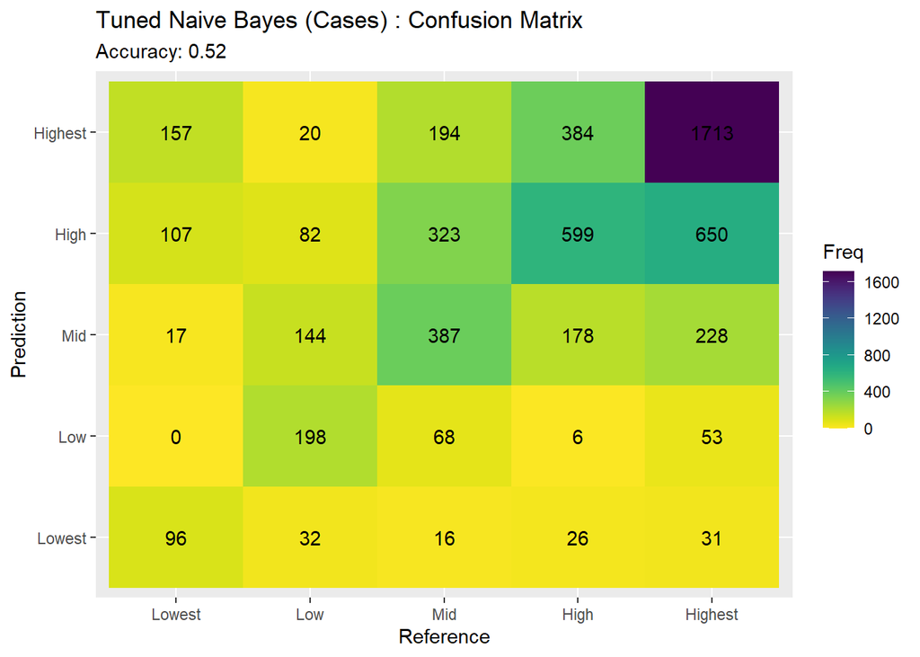

```r
#visualize the confusion matrix on the testing data
cmheatmap("Tuned Naive Bayes (Cases)", nbc_tuned_testing_cnfsmtrx)
```

The tuned Naïve Bayes model had a 52% accuracy, which is an improvement over the un-tuned model’s accuracy of 39%. Part of this improvement could also be due to the dataset used to train the model, which includes only complete cases, all observations with missing data were excluded from this analysis.

## Decision Tree

### Mortality

A Decision Tree is another machine learning algorithm which can be used for classification tasks. It takes labeled data, and then progressively splits the data based on certain decision points. This creates a visual tree-like structure with internal nodes (decision points), branches (rules), and leaf nodes (final result/ classification). A Decision Tree is a popular machine learning algorithm because it is very easily interpreted by the human mind, as it shows a step by step process for determining how to classify the outcome. Below a Decision Tree model will be developed to predict both the daily case rate, and the daily mortality rate.

```r
#create the decision tree
dtm_model <- rpart::rpart(deathcategory~.,
                       data = dfm_training,
                      method = "class")

#create a prediction based on the training data
dtm_training_predictions <- predict(dtm_model, dfm_training, type = "class")

#create a prediction on the testing data
dtm_testing_predictions <- predict(dtm_model, dfm_testing, type = "class")

#view the most important variables
as.data.frame(head(dtm_model$variable.importance))
```

|  | head(dtm_model$variable.importance) |
| --- | --- |
| new_cases_per_million | 14902.887 |
| total_cases_per_million | 6107.145 |
| human_development_index | 5006.678 |
| life_expectancy | 4847.903 |
| gdp_per_capita | 4194.709 |
| median_age | 3724.683 |

One important thing to review with Decision Trees is the Variable Importance. This identifies which variables in the model were most predictive. It can be seen above that the most important variables for predicting the daily mortality rate are the number of new cases and total cases, followed by four variables that are specific to each country (rather than to a particular day) such as the human development index, life expectancy, GDP and median age.

The actual Decision Tree can be seen below. The first node asks if the new cases per million were above or below 5.5. If they were below that, then the mortality rate for that day was most likely in the lowest category. If they are above that figure, then the next node asks if they were above or below 105. After that, there are several more splits looking at population, hospitalizations, new cases again, and GDP.

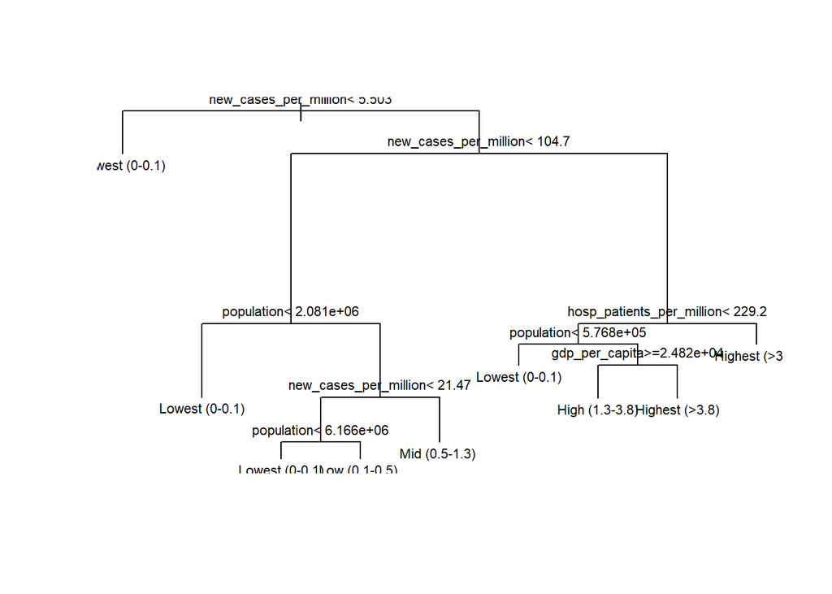

```r
#view the decision tree (using the base plot() function)
plot(dtm_model)
text(dtm_model, cex = 0.7)
```

[figure not shown]

```r
#view the decision tree (trying another different versions)
rattle::fancyRpartPlot(dtm_model, cex = 0.5, main = "Decision Tree (Mortality)")
```

```r
#check how well the prediction did on the training data using a confusion matrix
dtm_training_cnfsmtrx <- confusionMatrix(dfm_training$deathcategory, dtm_training_predictions)
dtm_training_cnfsmtrx$overall[1]
```

```
##  Accuracy
## 0.6210344
```

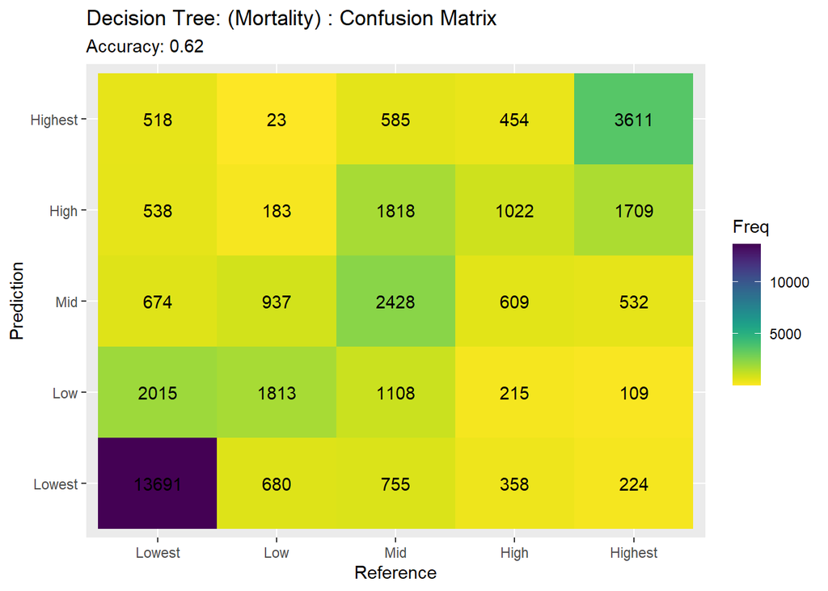

```r
#check how well the prediction did on testing using a confusion matrix
dtm_testing_cnfsmtrx <- confusionMatrix(dfm_testing$deathcategory, dtm_testing_predictions)

#visualize the confusion matrix on the testing data
cmheatmap("Decision Tree: (Mortality)", dtm_testing_cnfsmtrx)
```

The Decision Tree model has an accuracy rate of 62% on predicting mortality using the testing data. Because one of the main predictors for mortality was cases, the predictors for daily case rate will also be assessed using a decision tree model as well.

### Decision tree on case category

```r
#create the decision tree
dtc_model <- rpart::rpart(casecategory~.,
                       data = dfc_training,
                      method = "class")

#create a prediction based on the training data
dtc_training_predictions <- predict(dtc_model, dfc_training, type = "class")

#create a prediction on the testing data
dtc_testing_predictions <- predict(dtc_model, dfc_testing, type = "class")

#view the most important variables
as.data.frame(head(dtc_model$variable.importance))
```

|  | head(dtc_model$variable.importance) |
| --- | --- |
| human_development_index | 5420.454 |
| life_expectancy | 4169.347 |
| gdp_per_capita | 4090.838 |
| median_age | 3100.621 |
| aged_65_older | 2918.407 |
| new_tests_per_thousand | 2763.560 |

The Variable Importance measure shows that the factors that impact the prediction most include country-specific features such as the human development index, life expectancy, GDP, and the population’s age. Factors that change by day, such as the number of new tests are also included. The actual tree will be visualized below.

The first split in the decision tree is looking at the human development index (HDI). For countries with a lower HDI, the next factor to consider is the reproduction rate of the virus. For countries with a higher HDI, the next factor to consider is the number of new tests per thousand citizens.

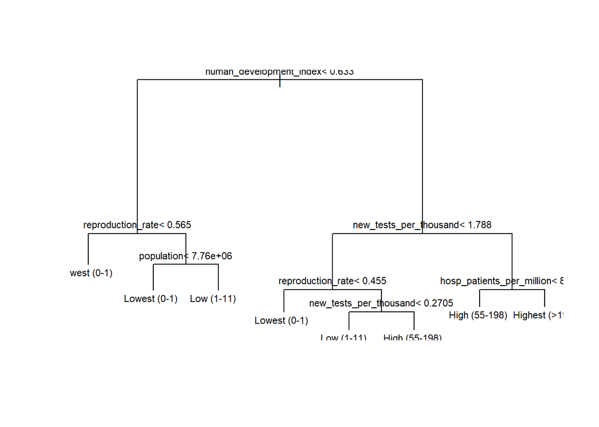

```r
#view the decision tree (using the base plot() function)
plot(dtc_model)
text(dtc_model, cex = 0.7)
```

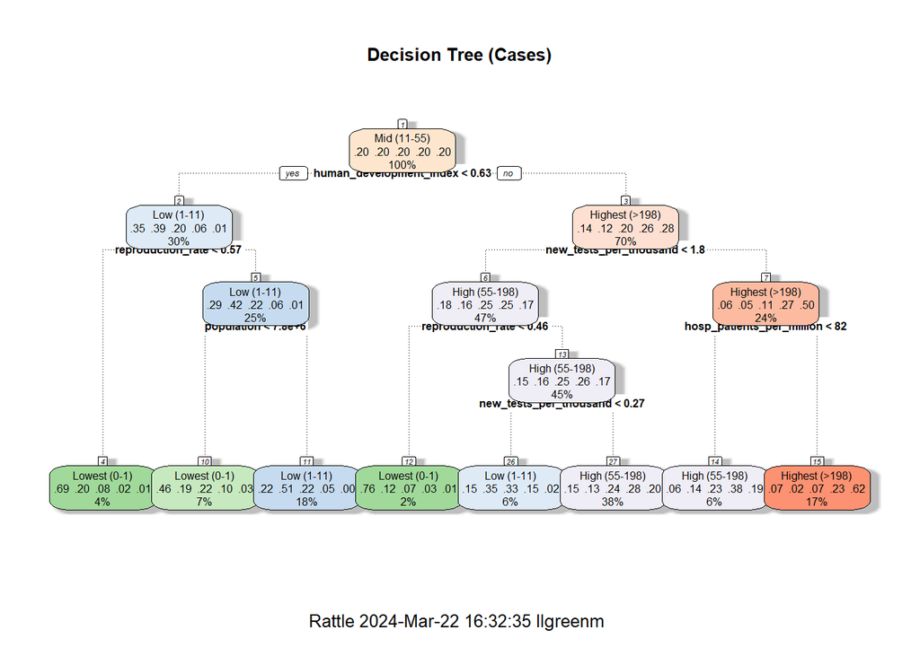

```r
#view the decision tree (trying another different versions)
rattle::fancyRpartPlot(dtc_model, cex = 0.5, main = "Decision Tree (Cases)")
```

```r
#check how well the prediction did on the training data using a confusion matrix
dtc_training_cnfsmtrx <- confusionMatrix(dfc_training$casecategory, dtc_training_predictions)
dtc_training_cnfsmtrx$overall[1]
```

```
##  Accuracy
## 0.4330283
```

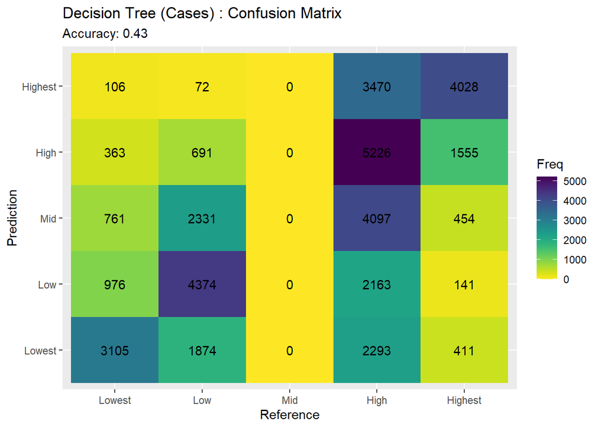

```r
#check how well the prediction did using a confusion matrix
dtc_testing_cnfsmtrx <- confusionMatrix(dfc_testing$casecategory, dtc_testing_predictions)

#visualize the confusion matrix on the testing data
cmheatmap("Decision Tree (Cases)", dtc_testing_cnfsmtrx)
```

The accuracy rate for the Decision Tree on daily cases is only 43%, and an interesting pattern appears. This model is not capturing days where the daily cases are in the mid-range. Because it was noted that many of the factors considered in this model are related to the country, rather than to the individual day, the next model will attempt to recreate a decision tree but separating countries out. The United States will be singled out in this case, to see what factors the model uses to predict the daily case rate when all of the country specific variables are constant.

### Decision tree on one country

```r
#United States population is 332915074
dfc_1c_training <- filter(dfc_training, population == 332915074)
dfc_1c_testing <- filter(dfc_testing,  population == 332915074)

#create the decision tree
dtc_1c_model <- rpart::rpart(casecategory~.,
                       data = dfc_1c_training,
                      method = "class")

#create a prediction based on the training data
dtc_1c_training_predictions <- predict(dtc_1c_model, dfc_1c_training, type = "class")

#create a prediction on the testing data
dtc_1c_testing_predictions <- predict(dtc_1c_model, dfc_1c_testing, type = "class")

#view the most important variables
as.data.frame(head(dtc_1c_model$variable.importance))
```

|  | head(dtc_1c_model$variable.importance) |
| --- | --- |
| new_tests_per_thousand | 139.14108 |
| hosp_patients_per_million | 82.67936 |
| total_tests_per_thousand | 77.27268 |
| icu_patients_per_million | 69.59350 |
| stringency_index | 65.41009 |
| reproduction_rate | 31.75184 |

The variables that are most important when looking at only one country (the United States) are the number of tests, hospitalizations, the stringency index and reproduction rate. The tree can be viewed below. The first decision is the number of new tests, followed by the stringency index.

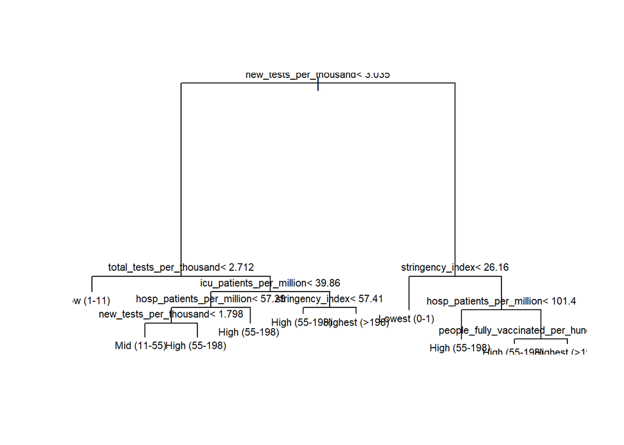

```r
#view the decision tree (using the base plot() function)
plot(dtc_1c_model)
text(dtc_1c_model, cex = 0.7)
```

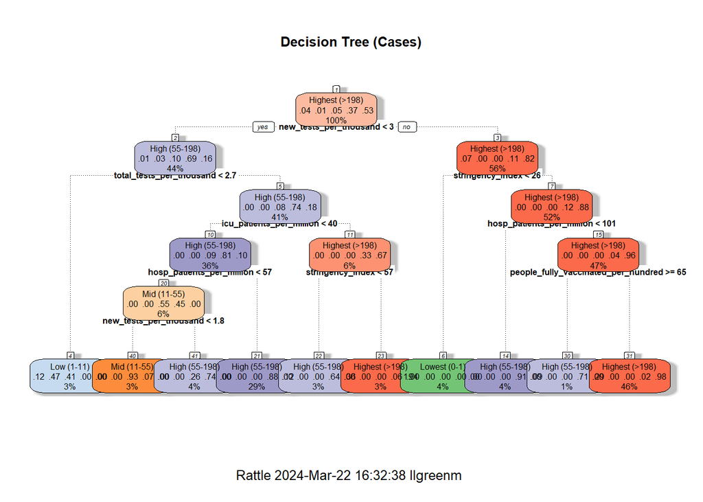

```r
#view the decision tree (trying another different versions)
rattle::fancyRpartPlot(dtc_1c_model, cex = 0.5, main = "Decision Tree (Cases)")
```

```r
#check how well the prediction did on the training data using a confusion matrix
dtc_1c_training_cnfsmtrx <- confusionMatrix(dfc_1c_training$casecategory, dtc_1c_training_predictions)
dtc_1c_training_cnfsmtrx$overall[1]
```

```
##  Accuracy
## 0.9072356
```

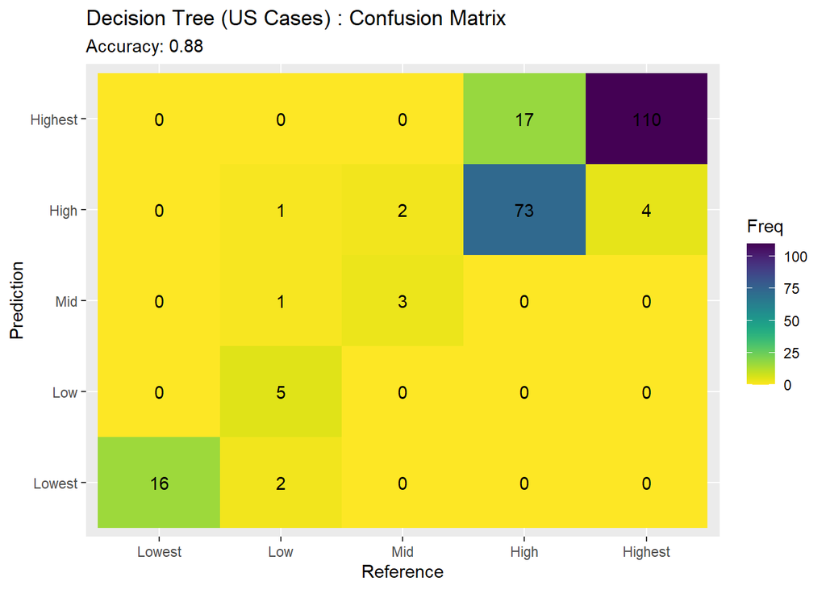

```r
#check how well the prediction did using a confusion matrix
dtc_1c_testing_cnfsmtrx <- confusionMatrix(dfc_1c_testing$casecategory, dtc_1c_testing_predictions)

#visualize the confusion matrix on the testing data
cmheatmap("Decision Tree (US Cases)", dtc_1c_testing_cnfsmtrx)
```

When limiting the Decision Tree model to one country at a time, the accuracy rate greatly increases. This model is able to predict the daily case rate with an 88% accuracy for the United States.

### Decision Tree Cases, One Country, Pruned

Now that a strong model has been identified, the model can be further tuned. The first step in pruning a decision tree is to assess the complexity factor, and the best level. The visual below indicates that the best level of complexity to cut the tree at would be 0.019.

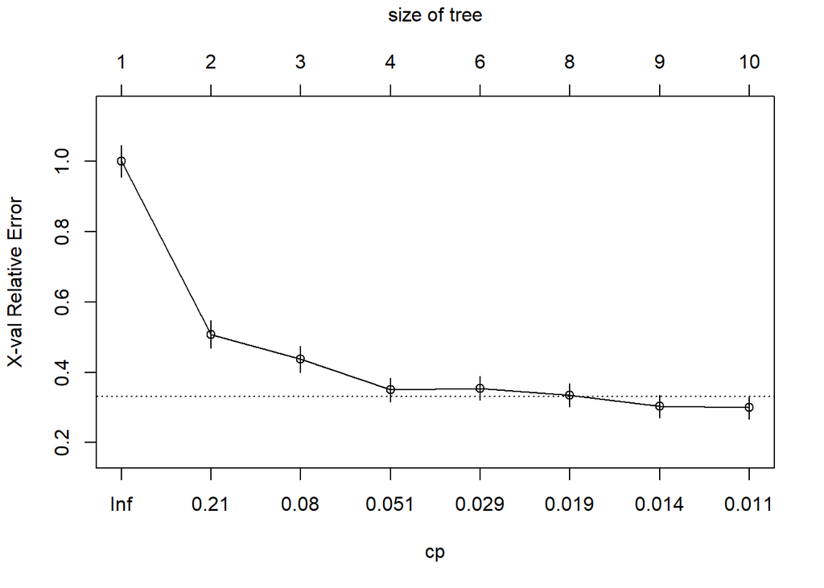

```r
#plot the complexity parameter
rpart::plotcp(dtc_1c_model)
```

```r
#prune the model based on the complexity parameter
dtc_1c_model_pruned <- rpart::prune(dtc_1c_model, cp = 0.019)

#create a prediction based on the training data
dtc_1cp_training_predictions <- predict(dtc_1c_model_pruned, dfc_1c_training, type = "class")

#check how well the prediction did using a confusion matrix
dtc_1cp_training_cnfsmtrx <- confusionMatrix(dfc_1c_training$casecategory, dtc_1cp_training_predictions)
dtc_1cp_training_cnfsmtrx$overall[1]
```

```
##  Accuracy
## 0.8942486
```

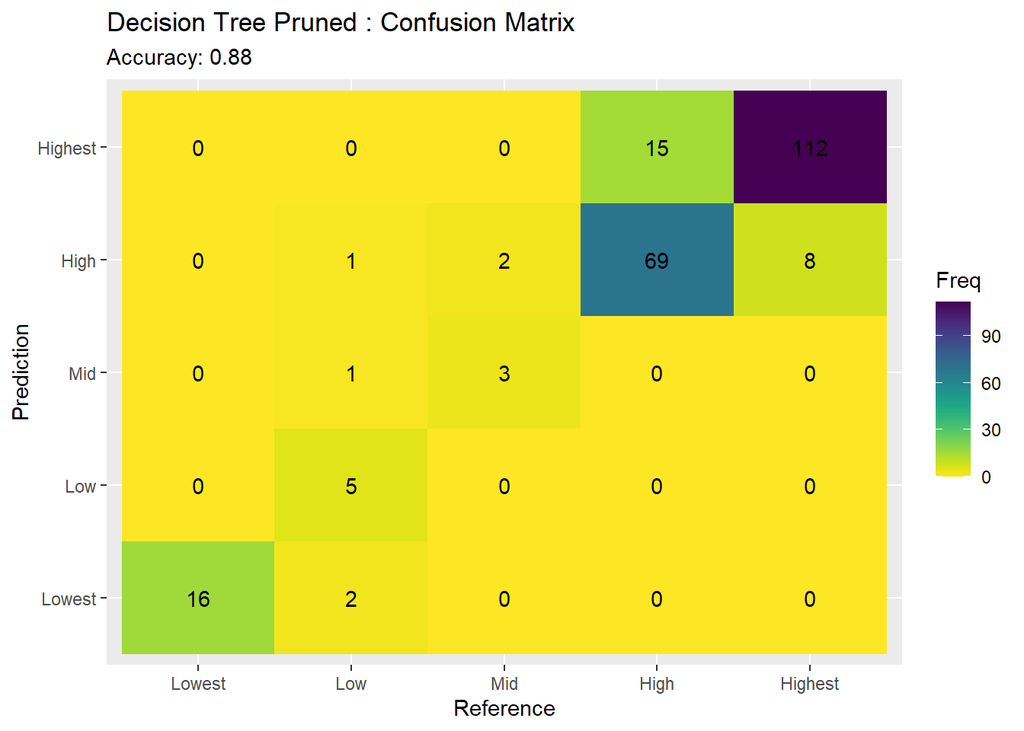

```r
#create a prediction on the testing data
dtc_1cp_testing_predictions <- predict(dtc_1c_model_pruned, dfc_1c_testing, type = "class")

#check how well the prediction did on testing data using a confusion matrix
dtc_1cp_testing_cnfsmtrx <- confusionMatrix(dfc_1c_testing$casecategory, dtc_1cp_testing_predictions)

#visualize the confusion matrix on the testing data
cmheatmap("Decision Tree Pruned", dtc_1cp_testing_cnfsmtrx)
```

The Confusion Matrix above shows that the accuracy level is still at 88%. This may be because the initial model developed without tuning was actually already performing as well as this type of model could with the data available.

# Results

The COVID-19 pandemic is something that impacted the lives of nearly every person on the planet. This type of global pandemic does not occur often, so it is important for public health professionals to be able to review the available data and use it to prepare for the next public health crisis.

Machine Learning techniques can help data scientists to find hidden trends in the data that might otherwise be difficult to identify. In this study, machine learning techniques were used to try and predict the burden of disease on a given population over time. The daily case rate and daily mortality rate were both used as outcome measures, and a variety of variables related to each individual nation’s overall status, and time sensitive daily changes were used as predictors. First, an exploratory data analysis was conducted to identify any potential issues with the data, or preliminary trends. A k-means clustering algorithm was used to cluster the countries by their lasting characteristics (life expectancy, hospital bed availability, human development index, extreme poverty etc), and key countries from each cluster were compared to look for differences overtime.

The data was pre-processed to remove excessive missing data before splitting it into training and testing data sets. Once split, it was used to train and then test Naïve Bayes, Decision Tree and K Nearest Neighbor models. A model was created to predict cases and another to predict mortality with each algorithm. In addition, each algorithm was then tuned to try and improve the accuracy of the model. A summary of the models developed can be found below.

The table below shows the accuracy results of the confusion matrices for each model, including the default version and all tuned models that were developed as well.

```r
#Gather accuracy results for all of the final testing models for each algorithm
rtTestingResults <- c(nbc_testing_cnfsmtrx$overall[1],
      nbm_testing_cnfsmtrx$overall[1],
      nbc_tuned_testing_cnfsmtrx$overall[1],
      dtc_testing_cnfsmtrx$overall[1],
      dtm_testing_cnfsmtrx$overall[1],
      dtc_1c_testing_cnfsmtrx$overall[1],
      dtc_1cp_testing_cnfsmtrx$overall[1],
      knnm_testing_cnfsmtrx$overall[1],
      knnc_testing_cnfsmtrx$overall[1],
      knnm_IT_testing_cnfsmtrx$overall[1]
      )

#Gather accuracy results for all of the final training models for each algorithm
rtTrainingResults <- c(nbc_training_cnfsmtrx$overall[1],
      nbm_training_cnfsmtrx$overall[1],
      nbc_tuned_training_cnfsmtrx$overall[1],
      dtc_training_cnfsmtrx$overall[1],
      dtm_training_cnfsmtrx$overall[1],
      dtc_1c_training_cnfsmtrx$overall[1],
      dtc_1cp_training_cnfsmtrx$overall[1],
      knnm_training_cnfsmtrx$overall[1],
      knnc_training_cnfsmtrx$overall[1],
      knnm_IT_training_cnfsmtrx$overall[1]
      )

#Create a vector with each model's name
rtCategories <- c("Naive Bayes Cases", "Naive Bayes Mortality", "Naive Bayes Tuned Cases" ,"Decision Tree Cases", "Decision Tree Mortality", "Decision Tree: 1 country", "Decision Tree Cases, 1 country, Tuned","KNN Mortality", "KNN Cases", "KNN Italian Mortality")

#create a table showing training and testing results for the models
rtResultTable <- data.frame(rtCategories, rtTrainingResults, rtTestingResults)

names(rtResultTable) <- c("Model Results", "Training Accuracy", "Testing Accuracy")

rtResultTable <- mutate_if(rtResultTable, is.numeric, round, digits =2)

rtResultTable
```

| Model Results | Training Accuracy | Testing Accuracy |
| --- | --- | --- |
| Naive Bayes Cases | 0.39 | 0.39 |
| Naive Bayes Mortality | 0.41 | 0.41 |
| Naive Bayes Tuned Cases | 0.53 | 0.52 |
| Decision Tree Cases | 0.43 | 0.43 |
| Decision Tree Mortality | 0.62 | 0.62 |
| Decision Tree: 1 country | 0.91 | 0.88 |
| Decision Tree Cases, 1 country, Tuned | 0.89 | 0.88 |
| KNN Mortality | 0.75 | 0.68 |
| KNN Cases | 0.79 | 0.73 |
| KNN Italian Mortality | 0.85 | 0.80 |

# Conclusions

After extensive research of determining different factors about COVID-19, there was some interesting and peculiar information that was landed upon. The biological horror of COVID-19 was one of a kind, potentially any other pandemics we have ever seen. In today’s society, there is an estimate that 7 million people have passed away due to the virus ever since the pandemic. COVID-19 had an incredible infection rate while its predecessor, the Spanish Flu, was more deadly. The reason why this is important to note is that, history tends to repeat itself. In the future, we cannot surely say that there will never be another pandemic because viruses have been around since the beginning of time. These resilient and adaptable beings have always found ways to become more powerful towards many living species. It is their way of life to infect and evolve.

The idea of this project was to determine key factors regarding how COVID-19 affected the different countries of the world. As stated before, the previous pandemic was the Spanish flu that took the lives of more than 20 million people! In terms of the two viruses, the procedures and processes of safety have improved. However, it is pertinent to continue improving to preserve more life down the way. In this study, the mortality (death rate), and incidence (case rate) of the disease will be the primary outcomes assessed. The available data will be evaluated to look for any trends that identify which factors lead to increased mortality and increased incidence of disease. Here are some of the key factors we noticed between our study.

- The range for daily mortality ranges from 0 to 453 deaths per million citizens
- The daily mortality rate increased as the amount of hospitalizations increased.
- The stringency index shows that the mortality rate decreases if a country has a higher stringency index
- There were three main clusters that included GDP, Life Expectancy, and Stringency Index

Each of the factors stated above determined how dangerous COVID-19 was to their economy. For example, China was able to contain the virus in the earlier stages to prevent any kind of further detriment. At the same time, Russia and the USA had much more difficult times containing the virus throughout the course of the pandemic. We also must take into fact the government itself. Though the stringency index can be quantified to a certain level, it cannot fully ascertain the volatility of a government. Multiple decisions are made based on the experience and each government is different from their counterparts. However, what we can deem is that the effective and swift utilization of protocol such as minimizing transportation, reducing foreign involvements, etc can lead to a more contained environment.

After looking for relationships and correlations, our next step was to take our analysis further with machine learning. Machine learning is a powerful tool in data analytics. Through various tools, we have the capability of categorizing, predicting, etc. Our goal for the project was to see if we could build a model that can determine outcomes using different aspects for the data. Here are the results we found from our machine learning methods!

**Naive Bayes**

- The model’s accuracy is 41%, so it does perform better than it would were there be to no information available.
- The tuned Naïve Bayes model had a 52% accuracy, which is an improvement over the un-tuned model’s accuracy of 39%.

**Decision Tree**

- The Decision Tree model has an accuracy rate of 62% on predicting mortality using the testing data. Because one of the main predictors for mortality was cases, the predictors for daily case rate will also be assessed using a decision tree model as well.
- The accuracy rate for the Decision Tree on daily cases is only 43%, and an interesting pattern appears. This model is not capturing days where the daily cases are in the mid-range.
- When limiting the Decision Tree model to one country at a time, the accuracy rate greatly increases. This model is able to predict the daily case rate with an 88% accuracy for the United States.
- Even when pruned, The Confusion Matrix above shows that the accuracy level is still at 88%.

In conclusion, global pandemics are always unpredictable and volatile. There are a number of circumstances that play into various factors. Even though understanding these factors, it can still be difficult to completely comprehend and hone in. However, data analytics does allow us to mitigate them. By performing all the research from COVID-19, we can develop appropriate measures and ideas from the results alone. For example, we were able to get an accuracy level of 88% for one of our machine learning tasks! Once again, there is the issue of obtaining everything as data and setbacks in terms of overfitting. But, we can definitely combat that by making sure to learn from our previous endeavors. Imagine what could happen if we were able to take data from various pandemics to build upon! Ultimately, this project does provide useful information on a public safety level. It provides the opportunity for insight and improvement as a whole!

```r
end_time <- Sys.time() #adding this just to track how long this takes
paste("This took",round(end_time - start_time, digits = 2), "minutes to run")
```

```
## [1] "This took 1.75 minutes to run"
```